# Mean Shift Clustering - Experimental Analysis

Quang Nguyen

2026-01-17

# 1 Introduction

This document presents experimental results for the Mean Shift Clustering algorithm. We focus on three key experiments:

1. **Varying Data Distributions**: Testing on different numbers of points and cluster densities
2. **Kernel Function Comparison**: Comparing Gaussian, Flat, and Epanechnikov kernels
3. **Bandwidth Sensitivity**: Analyzing the critical impact of bandwidth parameter selection

# 2 Experiment Setup

## 2.1 Data Generation Function

```r
#' Generate synthetic 2D blobs for clustering
#'
#' @param n_samples Total number of samples
#' @param centers Matrix of cluster centers
#' @param cluster_std Standard deviation of each cluster
#' @return List with data and true labels
generate_blobs <- function(n_samples, centers, cluster_std = 0.5) {
  n_centers <- nrow(centers)
  samples_per_cluster <- rep(n_samples %/% n_centers, n_centers)
  samples_per_cluster[1] <- samples_per_cluster[1] + (n_samples %% n_centers)

  data_list <- list()
  labels <- c()

  for (i in 1:n_centers) {
    n <- samples_per_cluster[i]
    cluster_data <- matrix(rnorm(n * 2, mean = 0, sd = cluster_std), ncol = 2)
    cluster_data[, 1] <- cluster_data[, 1] + centers[i, 1]
    cluster_data[, 2] <- cluster_data[, 2] + centers[i, 2]

    data_list[[i]] <- cluster_data
    labels <- c(labels, rep(i, n))
  }

  data <- do.call(rbind, data_list)
  list(data = data, labels = labels)
}

#' Evaluate clustering performance
#'
#' @param data Data matrix
#' @param result Mean shift result
#' @param true_labels Ground truth labels
#' @return Data frame with metrics
evaluate_clustering <- function(data, result, true_labels) {
  silhouette <- compute_silhouette(data, result$cluster_labels)
  ari <- compute_ari(true_labels, result$cluster_labels)

  data.frame(
    n_clusters = result$n_clusters,
    silhouette = round(silhouette, 3),
    ari = round(ari, 3),
    time_secs = round(result$computation_time, 3),
    mean_iterations = round(result$mean_iterations, 2)
  )
}
```

# 3 Experiment 1: Varying Data Distributions

**Objective**: Test Mean Shift on different blob configurations to understand how data characteristics affect performance.

## 3.1 Setup

```r
# Set seed for reproducibility
set.seed(42)

# Configuration 1: Sparse (100 points)
sparse_data <- generate_blobs(
  n_samples = 100,
  centers = matrix(c(0, 0, 5, 5, 10, 0), ncol = 2, byrow = TRUE),
  cluster_std = 0.5
)

# Configuration 2: Medium (500 points)
medium_data <- generate_blobs(
  n_samples = 500,
  centers = matrix(c(0, 0, 5, 5, 10, 0), ncol = 2, byrow = TRUE),
  cluster_std = 0.5
)

# Configuration 3: Dense overlapping (1000 points)
dense_data <- generate_blobs(
  n_samples = 1000,
  centers = matrix(c(0, 0, 3, 3, 6, 0), ncol = 2, byrow = TRUE),
  cluster_std = 0.8
)
```

## 3.2 Visualization: Data Configurations

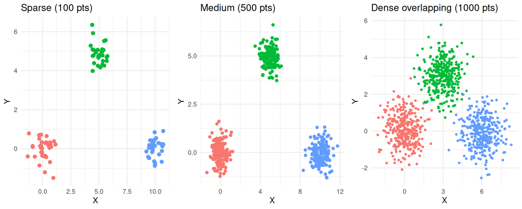

```r
# Plot all three configurations
p1 <- ggplot(data.frame(x = sparse_data$data[, 1],
                        y = sparse_data$data[, 2],
                        cluster = factor(sparse_data$labels))) +
  geom_point(aes(x = x, y = y, color = cluster), size = 2) +
  labs(title = "Sparse (100 pts)", x = "X", y = "Y") +
  theme_minimal() +
  theme(legend.position = "none")

p2 <- ggplot(data.frame(x = medium_data$data[, 1],
                        y = medium_data$data[, 2],
                        cluster = factor(medium_data$labels))) +
  geom_point(aes(x = x, y = y, color = cluster), size = 1.5) +
  labs(title = "Medium (500 pts)", x = "X", y = "Y") +
  theme_minimal() +
  theme(legend.position = "none")

p3 <- ggplot(data.frame(x = dense_data$data[, 1],
                        y = dense_data$data[, 2],
                        cluster = factor(dense_data$labels))) +
  geom_point(aes(x = x, y = y, color = cluster), size = 1) +
  labs(title = "Dense overlapping (1000 pts)", x = "X", y = "Y") +
  theme_minimal() +
  theme(legend.position = "none")

grid.arrange(p1, p2, p3, ncol = 3)
```